[figure not shown]

# Дипломный проект «Автоматизация учёта заказов на примере компании "SoleBay"»

## Обучающийся: Банных Вадим Витальевич

### Руководитель: Гринева Елиза

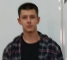

- Можете ещё раз четко сказать что такое декомпозиция
  - Предоставление информации в более четком виде и удобном виде (ответ был мутным)
  - Мелкие схемы

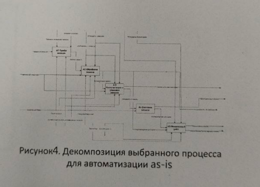

- стек технологий
  - C# VisualStudio ASP.NET Framework, Windows Form
  - Использовал PNG-картинки для имитации интерфейса.
  - Видео доказательства работоспособности функционала нет
  - Есть версия для слабовидящих
- Где в дипломе описание характеристик баз данных
  - сказал что текстом в дипломе написано...

# Дипломный проект на тему «Автоматизация процесса управления транспортной Логистики на примере О0 "Траско Тех'»

Обучающийся: Батыршин Константин Алексеевич Руководитель: Мастяев Филипп

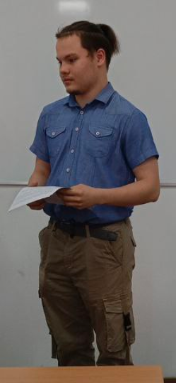

в ответах фигурировал c# 1c json gprs

по большей части было молчание

Та и не услышали технических связок кроме отдельных слов с необоснованными связями

В ответе Батыршина Константина Алексеевича, описывалась разработка приложения с использованием C#. Возможные технологии построения графического интерфейса WFP/WinForm, этот момент не столь важен.

Фигурировал выбор адреса. Построение маршрута на карте до выбранного адреса.

Что было не так. Во первых, графические возможности C#, WinForm, WPF позволяют строить не сложную графику и по объему они описаны в учебниках по 1000-1500 страниц. Объем необходимого материала "за гранью добра и зла"...

Есть (ожидалось) BitMap/Canvas/SVG/Brush ... Вопросы заданы про это.

В ответе прозвучало затрудняюсь ответить сразу после небольшой задержки. Материалом простейшей компьютерной графики студент не владеет. Соответственно решать вопросы отображения графики карты в C# - на данный момент не способен.

В дальнейшем сумбурном ответе прозвучали 1С, JSON, GPS , возможно ГЛОНАСС .

Без описания как они использовались и прикручивались к приложению это звучало как произвольный набор фраз

Кто-то из коллег сделал предположение, о том что интерфейс в само приложение мог быть вставлен картинкой.

# Дипломный проект на тему "Автоматизация контроля обслуживания техники на базе "АвтоВаз""

### Обучающийся: Большаков Никита Сергеевич

### Руководитель: Жданцев Кирилл Николаевич

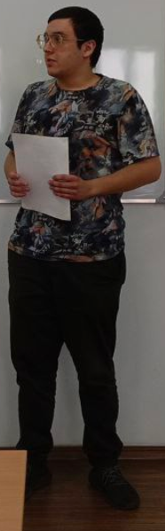

- Откройте, пожалуйста, слайд презентации со схемой базы данных.
  - Её нет
  - Ее нет в раздатке
  - Она есть в дипломе
- Дальше спрашивал не я.
- Есть ли человек, который проверяет датчики станков?
  - Датчики настраиваются только один раз.
  - Информация считывается только по показаниям датчиков.

# Дипломный проект на тему «Автоматизация анализа продаж Технониколь».

### Обучающийся: Засорин Артём Андреевич.

### Руководитель: Жданцев Кирилл Николаевич.

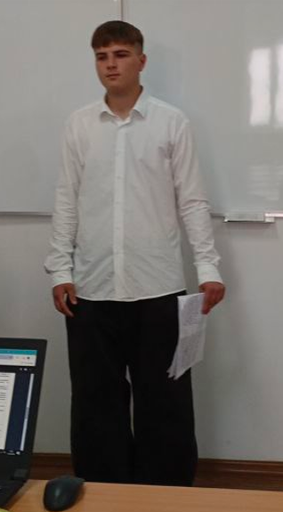

- Какая база данных наиболее типична для питона?
  - MySQL. (не верно)
- ПИТОН, НАКАТЫВАНИЕ БИБЛИОТЕК КАК ПРОИСХОДИТ?
  - ЧЕРЕЗ ТЕРМИНАЛ.
- КАК НАЗЫВАЕТСЯ МЕНЕДЖЕР РЕКОМЕНДУЕМОЙ УКАЧКИ ПАКЕТОВ?
  - ЗАТРУДНЯЮСЬ ОТВЕТИТЬ.

# Проект на тему «Интеграция модулей при автоматизации продаж товаров и услуг на примере ООО "Игрушка"».

### Обучающийся: Кацапов Данила Сергеевич.

### Руководитель: Алексахина Светлана Александровна.

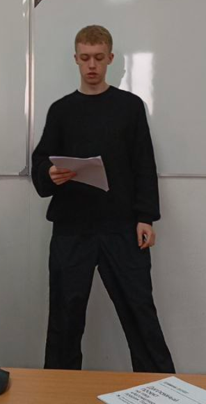

- Откройте, пожалуйста, слайд презентации со схемой базы данных.
  - В презентации ее нет.
  - Модель скрином в дипломе и к ней вопросы...

# Дипломный проект на тему: Автоматизации контроля исполнения заданий на примере компании ООО «Сфинкс»

### Обучающийся: Күлеша Александр Григорьевич

### Руководитель: Горшкова Анастасия Анатольевна

[figure not shown]

Вопросы не задавал

# Дипломный проект «Автоматизированной системы документооборота "Фирма 1С"»

### Обучающийся: Лесина Андрея Владимировича

### Руководитель: Скопин Владимир Игоревич.

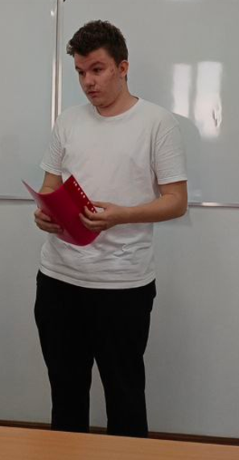

- вопросов не задавал, там и без меня хватило. Какого числа отправлена работа в LMS?
  - В ИЮНЕ.

# Дипломный проект на тему Автоматизация учета заказов на примере организации «Юкс»

### Обучающийся: Мустаков Магомед Русланович

### Руководитель: Горшкова Анастасия Анатольевна

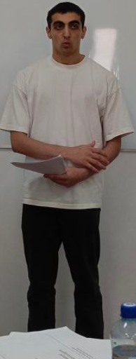

- Вопросов не задавал. Там и без меня хватало.
- Версия Битрикса для учащихся?
  - Затрудняюсь ответить.
- Какие способы интеграции с 1С вы знаете?
  - Rest API.

# Дипломный проект на тему «Автоматизация управления проектами на примере ООО "Kaf"»

### Обучающийся: Острецов Пётр Эдуардович

### Руководитель: Ребус Наталья Анатольевна

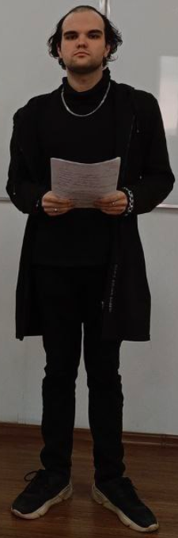

- +1
- Вопросов не задавал

# Дипломный проект на тему « Автоматизация процесса продажи на примере ООО «КнигаМир» »

### Обучающийся: Рахимов Дмитрий Олегович

### Руководитель: Горшкова Анастасия Анатольевна

[figure not shown]

- Как называется эта схема в оригинале на английском? И как переводится это название на русский?
  - Тишина.
- В какой программе она создается?
  - В PowerPoint. (Комментарий члена комиссии. Это мыслительная карта, которую можно создать в Freeplane.) (Комментарий члена комиссии. Mind map переводится как мыслительная или ментальная карта…)

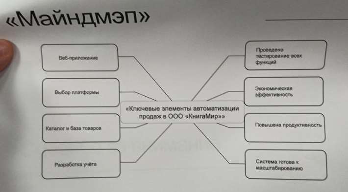

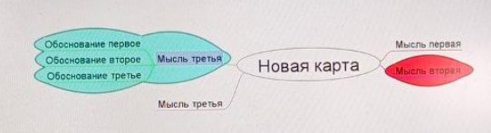